# Harry Smith DE analysis report

Harrison

2020-05-15

### **Methods**

For gathering genes per subset of pathway I used the MsigDB

I then subset the genes into the provided count matrix for each pathway geneset. I lost a few genes per subset that were not in the counts matrix

Before creating the deseq object I check to see if all samples in the meta data table match the counts matrix columns(samples). The sample X21630 was not in the meta data and was removed from the count matrix to continue

I then inputted the subsetted counts matrices into their own respective deseq object

For DE analysis of count data I inputted the design into the deseq object like this :

> design = ~Phenotype + Gender

For PCA I gathered components based on the subsetted counts matrices for each pathway geneset.

The results from DE indicated no values with FDR < .05 and pvalue was used instead.

Only one gene that satisfied pvalue < .05 & log2FC > | 1.5| and the rest were colored by significance rather than significance and fold change.

### **PCAs of all pathway genes**

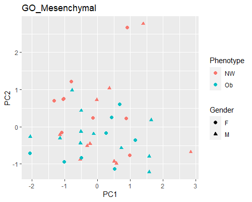

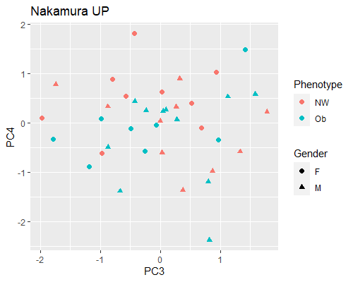

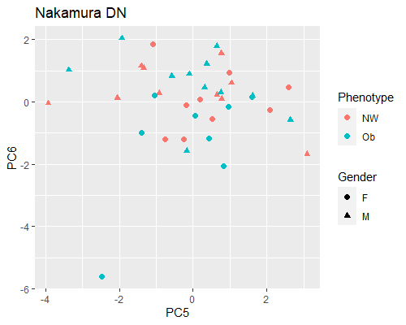

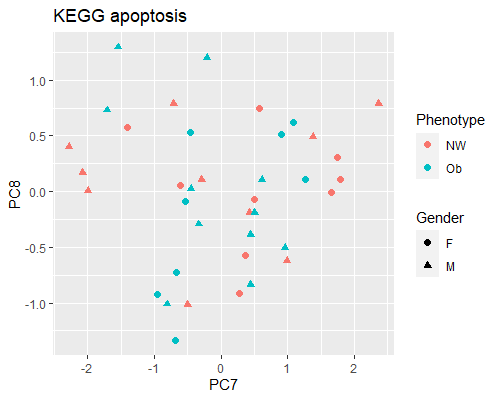

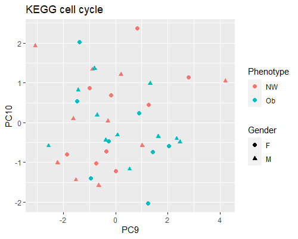

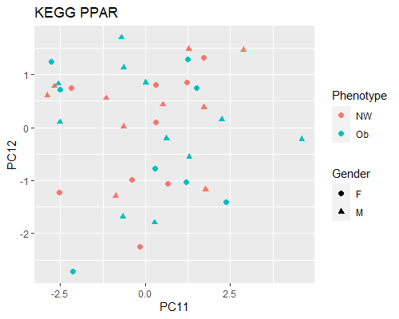

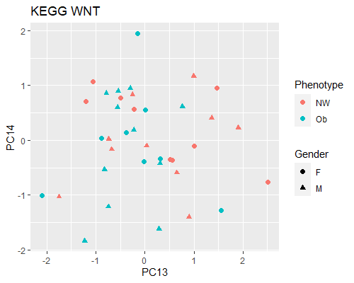

### **Top genes of all Pathways(Pvalues < .05)**

#### **Ob vs NW (GO Mesenchymal)**

[interactive chart not shown]

#### **Ob vs NW (Nakamura Up)**

[interactive chart not shown]

#### **Ob vs NW (Nakamura Dn)**

[interactive chart not shown]

#### **Ob vs NW (KEGG apoptosis)**

[interactive chart not shown]

#### **Ob vs NW (KEGG cell cycle)**

[interactive chart not shown]

#### **Ob vs NW (KEGG PPAR)**

[interactive chart not shown]

#### **Ob vs NW (KEGG WNT)**

[interactive chart not shown]

### **Volcano Plots**

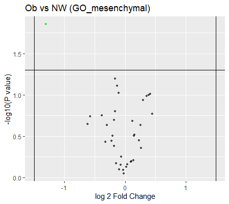

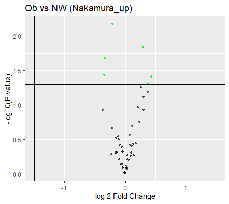

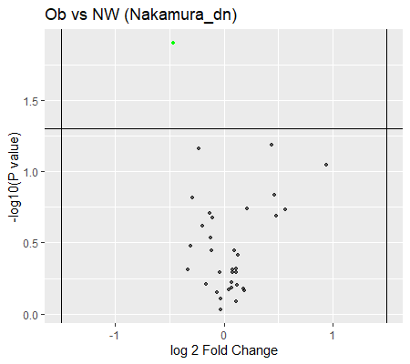

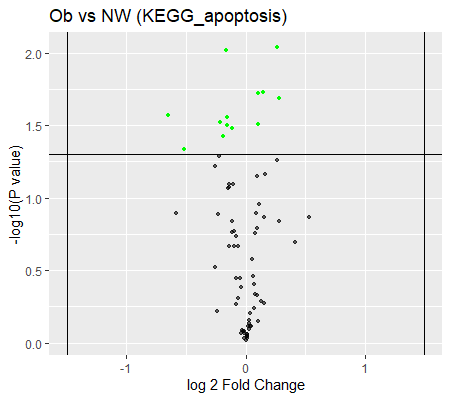

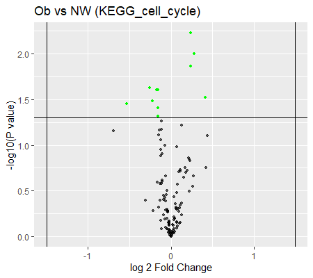

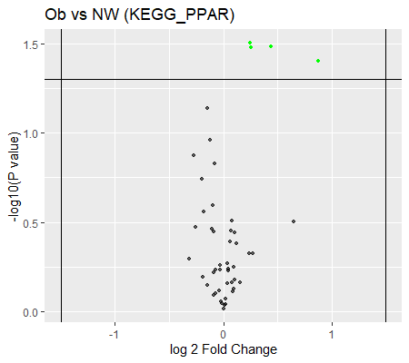

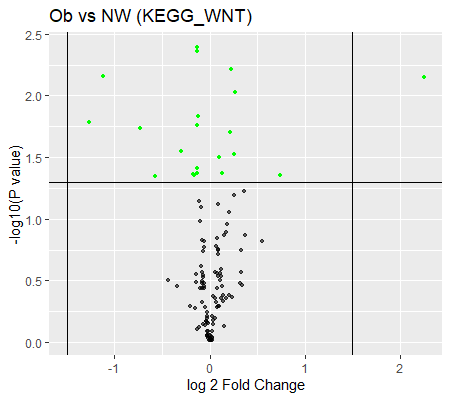